# Federico Mattiello’s CV

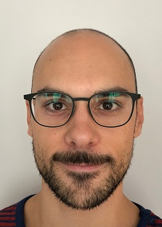

profile

# Federico Mattiello

Senior Statistician in the “Pharma Development Biometrics Biostatistics” unit at Roche

@gmail @roche | [LinkedIn](https://www.linkedin.com/profile/view?id=125233914), Phone: +41 76 815 02 01

## Currently (03/2016 - today)

Senior Statistical Scientist at Roche, working on clinical development programs and company-wide projects

### Specialized in

Clinical trial design and simulation, permutation tests and NonParametric Combination Methodology

### Research interests

high-dimensional data analysis, Probabilistic Index Models, simulation, modelling, statistical learning

## Education

`04/2012 - 02/2016` **Researcher/Ph.D. Student** Department of *Mathematical Modelling, Statistics and Bioinformatics*, Ghent University, Gent. *Topics:* data integration in drug-development, analysis of microbiome sequencing data.

`10/2010 - 02/2015` **Ph.D. degree** at Department of Statistical Sciences, University of Bologna.  
Thesis: *“Permutation-Based Stochastic Ordering Using Pairwise Comparisons”* [direct link](http://amsdottorato.unibo.it/6735/1/Mattiello_Federico_tesi.pdf)

`10/2004-07/2010` **University of Padova** Bachelor (2004–2008) and Master (2008-2010) in “Statistics and Informatics”

## Research Collaborations

**IAP-StUDyS (2014-2016):** network of EU-funded projects (*“Phase VII”*). Topic: developing models for *microbiome 16S sequencing data*.

**QSTAR: (2012-2014)** project co-funded by IWT (flemish government agency) and Janssen Pharmaceutica. Topic: assess benefits of integrating *transcriptomics data* into early-stage drug development.

## Skills

### **Hard Skills**

**R:** power user

**Git/GitHub:** intermediate

**reporting:** in particular with *Rmarkdown, LaTeX*.

**Shiny:** to develop interactive web applications with *R*.

**Others:** some experience with *python*, *C++*, *Linux* OS,

### *Soft Skills*

I love to *learn*, culturally and scientifically speaking, curiosity is my strongest point.  
Trying to understand *“the why”* and how things/processes work is what motivates me, I strive to constantly improve my *system awareness*. Presenting to a non-statistical audience it’s fun, because messages need to be communicated effectively, complexity needs to be simplified. I’m open-minded and collaborative when in a team, but if I see that something can be done better by myself I go for it.

## Personal Interests

I love reading books about statistics, mathematics, popular science (physics, mathematics, logic), psychology, oriental philosophy, and novels dealing with journeys and different cultures. I also love independent movies, my favourite ones come from Italy, Japan, Korea, France, U.K., and Bollywood.

## Work Experience

**Teaching:** *“introductory statistics”* to political sciences’ students,  
**Tutoring:** fellow students for master course of *“Advanced Statistics”*  
**Data-entry:** and analysis of perceived chemical risk in food.  
**Summer jobs:** tile poser, electrician, construction of security glasses.

## Languages

*Italian:* native language,  
*English* at C1 level (professional and not), *Dutch* at B1 level, *German* and *Spanish* as a beginner A1/A2.